# GPS EDA

Author

Kendra wyant

Published

November 11, 2026

## Read in data

STARTS WITH GPS SAMPLE AND TRUNCATED END DATES BASED ON EMA

N = 296 (same as study_risk2)

```r
study_dates <- read_csv(here::here(path_shared, "study_dates_gps.csv"),
                show_col_types = FALSE) |>
  rename(study_end_ad_ema = study_end_ad) |>
  glimpse()
```

```
Rows: 296
Columns: 5
$ subid            <dbl> 1006, 1009, 1012, 1014, 1020, 1022, 1023, 1027, 1029,…
$ study_start      <date> 2021-04-21, 2021-05-03, 2021-09-15, 2021-10-27, 2022…
$ study_end        <date> 2022-04-29, 2022-05-09, 2022-10-05, 2022-11-03, 2023…
$ ema_end          <date> 2022-04-24, 2022-05-09, 2022-10-05, 2022-10-25, 2022…
$ study_end_ad_ema <date> 2022-04-24, 2022-05-09, 2022-10-05, 2022-10-25, 2022…
```

```r
gps <- read_csv(here::here(path_shared, "gps_counts.csv"),
                show_col_types = FALSE) |>
  rename(study_start = onboarding) |>
  filter(subid %in% study_dates$subid) |>
  glimpse()
```

```
Rows: 78,445
Columns: 4
$ subid       <dbl> 1006, 1006, 1006, 1006, 1006, 1006, 1006, 1006, 1006, 1006…
$ date        <date> 2021-04-21, 2021-04-22, 2021-04-23, 2021-04-24, 2021-04-2…
$ n           <dbl> 36, 679, 230, 388, 351, 194, 467, 22, 382, 124, 330, 352, …
$ study_start <date> 2021-04-21, 2021-04-21, 2021-04-21, 2021-04-21, 2021-04-2…
```

```r
length(unique(gps$subid))
```

```
[1] 296
```

## GPS Adherence for next 28 days

Create days on study tibble

- End 28 days before study end date (because looking at rolling compliance averages over 28 days)
- Get all study days for each subid

```r
# function to map over
get_study_days <- function(the_subid, dates) {
  study_start <- dates |>
    filter(subid == the_subid) |>
    pull(study_start)
  study_end <- dates |>
    filter(subid == the_subid) |>
    pull(study_end_ad_ema)
  if(study_end - study_start > 28) {
    study_days <- tibble(subid = the_subid,
                       study_day = seq(study_start,
                                       study_end - days(28),
                                       by = "day"))
    return(study_days)
  }
}

sub_days <- study_dates$subid |>
  map_dfr(~get_study_days(.x, study_dates)) |>
  glimpse()
```

```
Rows: 74,390
Columns: 2
$ subid     <dbl> 1006, 1006, 1006, 1006, 1006, 1006, 1006, 1006, 1006, 1006, …
$ study_day <date> 2021-04-21, 2021-04-22, 2021-04-23, 2021-04-24, 2021-04-25,…
```

Still N = 296

```r
length(unique(sub_days$subid))
```

```
[1] 296
```

Add counts to study days

```r
gps <- gps |>
  rename(study_day = date) |>
  right_join(sub_days, by = c("subid", "study_day")) |>
  mutate(n = if_else(is.na(n), 0, n)) |>
  arrange(subid, study_day) |>
  glimpse()
```

```
Rows: 74,390
Columns: 4
$ subid       <dbl> 1006, 1006, 1006, 1006, 1006, 1006, 1006, 1006, 1006, 1006…
$ study_day   <date> 2021-04-21, 2021-04-22, 2021-04-23, 2021-04-24, 2021-04-2…
$ n           <dbl> 36, 679, 230, 388, 351, 194, 467, 22, 382, 124, 330, 352, …
$ study_start <date> 2021-04-21, 2021-04-21, 2021-04-21, 2021-04-21, 2021-04-2…
```

Tail of distribution of gps points per day

```r
janitor::tabyl(gps$n) |>
  head(n = 100)
```

```
 gps$n     n     percent
     0 11415 0.153448044
     1   652 0.008764619
     2   702 0.009436752
     3   556 0.007474123
     4   521 0.007003630
     5   472 0.006344939
     6   486 0.006533136
     7   368 0.004946901
     8   344 0.004624277
     9   367 0.004933459
    10   325 0.004368867
    11   381 0.005121656
    12   318 0.004274768
    13   289 0.003884931
```

[output cut: 86 more lines]

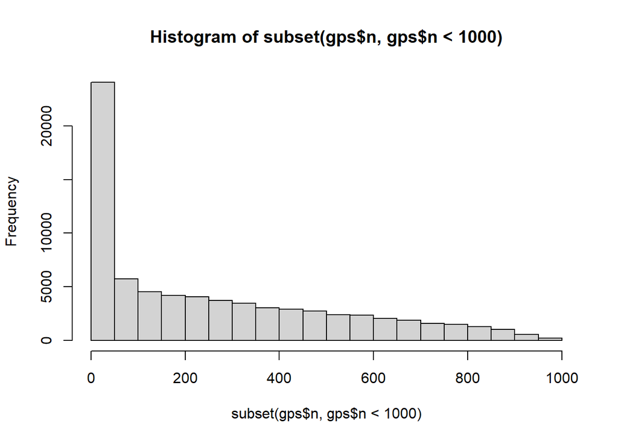

```r
hist(subset(gps$n, gps$n < 1000))
```

3 SUBIDS HAVE 0 GPS POINTS RETAINED WHEN LAST 28 DAYS ON STUDY FILTERED OUT

```r
gps |> filter(n > 0) |> select(subid) |>  distinct() |> nrow()
```

```
[1] 293
```

- 1088 gps data started 5/28/22 (within 22 days of EMA adjusted end date)
- 1258 gps data started 3/30/23 (within 10 days of EMA adjusted end date)
- 1366 gps data started 7/12/23 (within 23 days of EMA adjusted end date)

```r
subs <- gps |> filter(!subid %in% subset(gps, n > 0)$subid) |> pull(subid) |>  unique()

study_dates |>
  filter(subid %in% subs) |>
  mutate(days_on_study = study_end_ad_ema - study_start)
```

```
# A tibble: 3 × 6
  subid study_start study_end  ema_end    study_end_ad_ema days_on_study
  <dbl> <date>      <date>     <date>     <date>           <drtn>
1  1088 2022-05-20  2023-03-03 2023-01-12 2022-06-19       30 days
2  1258 2023-01-25  2023-11-09 2023-10-12 2023-04-10       75 days
3  1366 2023-07-05  2024-04-30 2024-05-02 2023-08-04       30 days
```

Calculate number of days with at least 1 gps point over next 28 days for each subid and study_day in sub_days

```r
gps_count <- sub_days |>
  left_join(gps |>
              filter(n > 0) |>
              rename(gps_day = study_day),
            by = c("subid"),
            relationship = "many-to-many") |>
  arrange(subid, study_day) |>
  filter(gps_day > study_day & gps_day <= study_day + 28) |>
  group_by(subid, study_day) |>
  summarise(n_gps_days = n(),
            .groups = "drop")
```

Calculate adherence for 28 day windows

```r
gps_count <- gps_count |>
  mutate(n_days = 28,
         adherence = n_gps_days/n_days)
```

Add day number indicator

```r
gps_count <- gps_count |>
  group_by(subid) |>
  mutate(day_num = row_number()) |>
  ungroup() |>
  glimpse()
```

```
Rows: 70,551
Columns: 6
$ subid      <dbl> 1006, 1006, 1006, 1006, 1006, 1006, 1006, 1006, 1006, 1006,…
$ study_day  <date> 2021-04-21, 2021-04-22, 2021-04-23, 2021-04-24, 2021-04-25…
$ n_gps_days <int> 28, 28, 28, 28, 28, 28, 28, 28, 28, 28, 28, 28, 28, 28, 28,…
$ n_days     <dbl> 28, 28, 28, 28, 28, 28, 28, 28, 28, 28, 28, 28, 28, 28, 28,…
$ adherence  <dbl> 1, 1, 1, 1, 1, 1, 1, 1, 1, 1, 1, 1, 1, 1, 1, 1, 1, 1, 1, 1,…
$ day_num    <int> 1, 2, 3, 4, 5, 6, 7, 8, 9, 10, 11, 12, 13, 14, 15, 16, 17, …
```

### Update study end dates

Add new study end column that will be updated

STARTS WITH TRUNCATED EMA END DATE

```r
study_dates <- study_dates |>
  mutate(study_end_ad_gps = study_end_ad_ema)
```

Set compliance threshold for discontinuing.

1. Any time adherence over the next 28 days falls below .33 discontinuation will be considered.
2. If adherence is below .33 for the majority of remaining days on study (< .75) they will be dropped.
3. If adherence is below .33 for less than the majority of remaining days on study (>= .75) they will be retained.
4. Discontinuation is considered every time adherence falls below .33

```r
for (sub in unique(gps_count$subid)) {
  study_days <- pull(subset(gps_count, subid == sub), study_day)
  adherence <- pull(subset(gps_count, subid == sub), adherence)

  for (i in seq_along(adherence)) {

    if(adherence[i] < .33) {

      prop_g_33 <- mean(adherence[i:length(adherence)] > .33)

      if(prop_g_33 < .75) {
        study_dates <- study_dates |>
          mutate(study_end_ad_gps = if_else(subid == sub, study_days[i], study_end_ad_gps))
        break
      }
    }
  }
}
```

293 subids have updated study_end dates

```r
study_dates |>
  filter(study_end_ad_ema != study_end_ad_gps) |>
  glimpse()
```

```
Rows: 293
Columns: 6
$ subid            <dbl> 1006, 1009, 1012, 1014, 1020, 1022, 1023, 1027, 1029,…
$ study_start      <date> 2021-04-21, 2021-05-03, 2021-09-15, 2021-10-27, 2022…
$ study_end        <date> 2022-04-29, 2022-05-09, 2022-10-05, 2022-11-03, 2023…
$ ema_end          <date> 2022-04-24, 2022-05-09, 2022-10-05, 2022-10-25, 2022…
$ study_end_ad_ema <date> 2022-04-24, 2022-05-09, 2022-10-05, 2022-10-25, 2022…
$ study_end_ad_gps <date> 2022-03-18, 2022-04-02, 2022-08-29, 2022-09-17, 2022…
```

265 have at least 28 days on study with new end date

```r
study_dates <- study_dates  |>
  mutate(on_study = as.numeric(study_end_ad_gps - study_start)) |>
  filter(on_study >= 28)

nrow(study_dates)
```

```
[1] 265
```

79493 labels (compared to 82,156 labels in study_risk2)

```r
get_labels <- function(the_subid, dates) {

  study_start <- dates |>
    filter(subid == the_subid) |>
    pull(study_start)

  study_end <- dates |>
    filter(subid == the_subid) |>
    pull(study_end_ad_ema)

  if (study_end == study_start) {
      study_days <- tibble(subid = the_subid,
                         study_day = seq(study_start, study_end,
                                         by = "day"))
  }

  if (study_end != study_start) {
      study_days <- tibble(subid = the_subid,
                         study_day = seq(study_start, study_end - days(1),
                                         by = "day"))
    }

  return(study_days)
}
```

```r
unique(study_dates$subid) |>
  map_dfr(~get_labels(.x, study_dates)) |>
  nrow()
```

```
[1] 79493
```

save out study dates

```r
study_dates |>
  write_csv(here::here(path_shared, "study_dates_gps_ad.csv"))
```

### Plot next 28-day adherence

```
$`1`
```

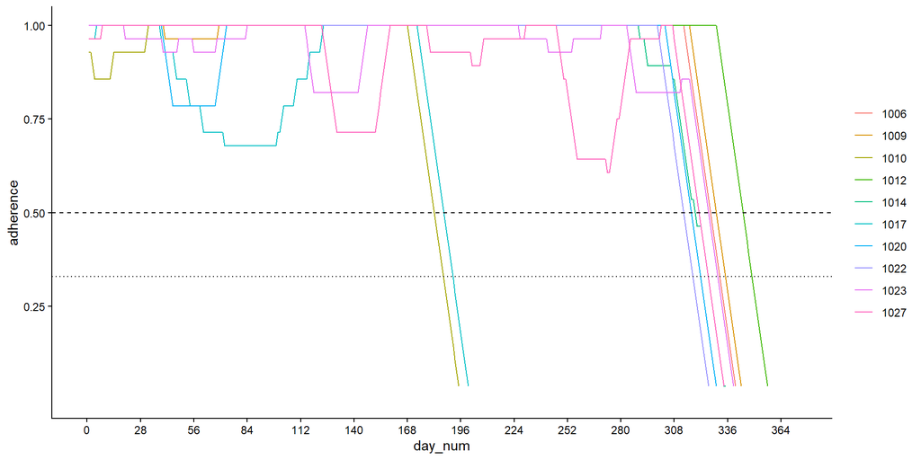

```
$`2`
```

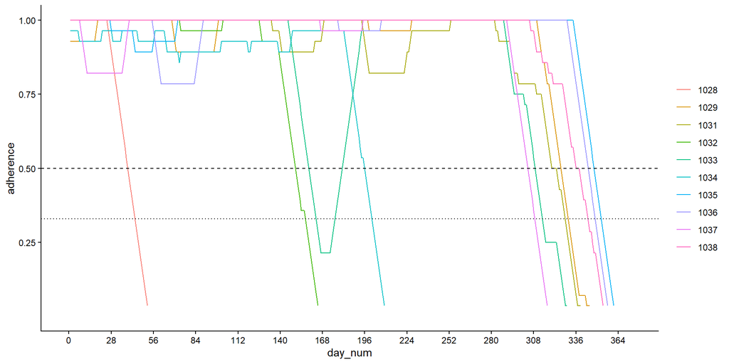

```
$`3`
```

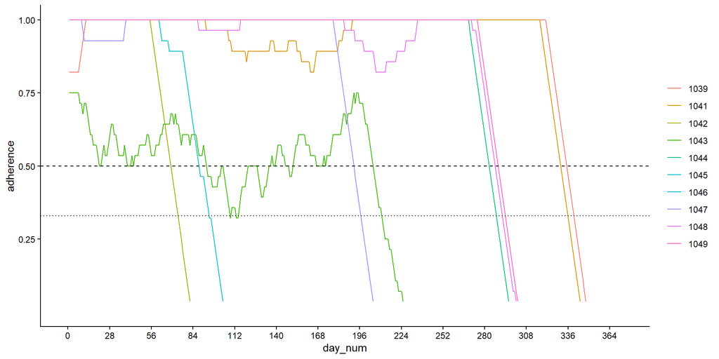

```
$`4`
```

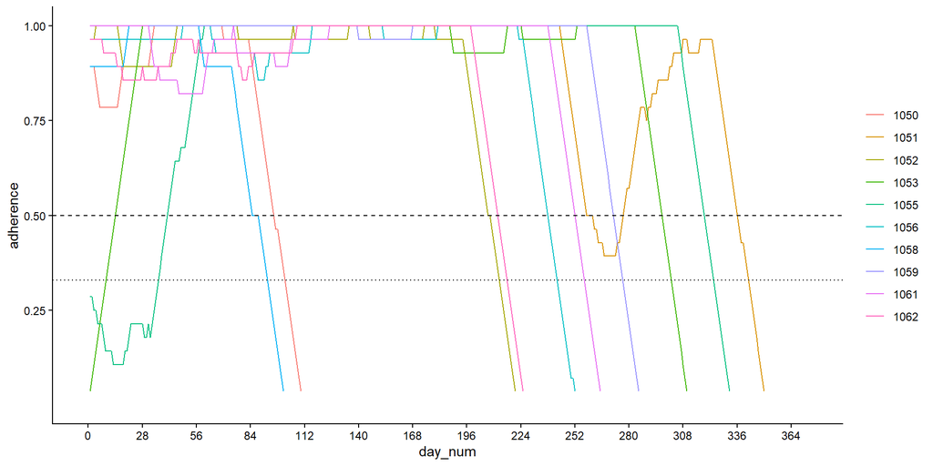

```
$`5`
```

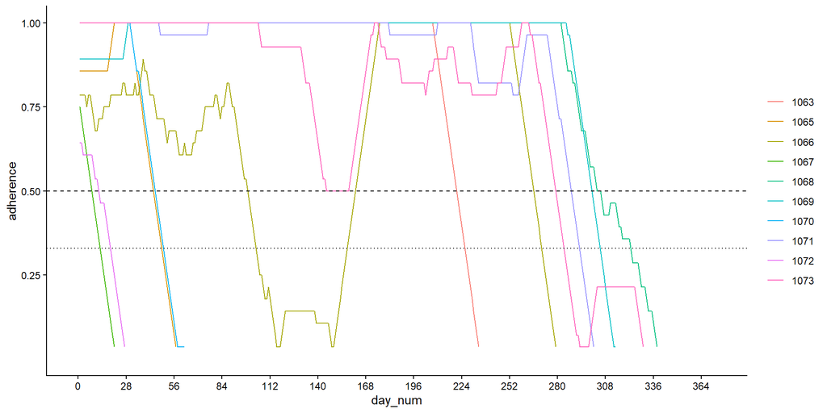

```
$`6`
```

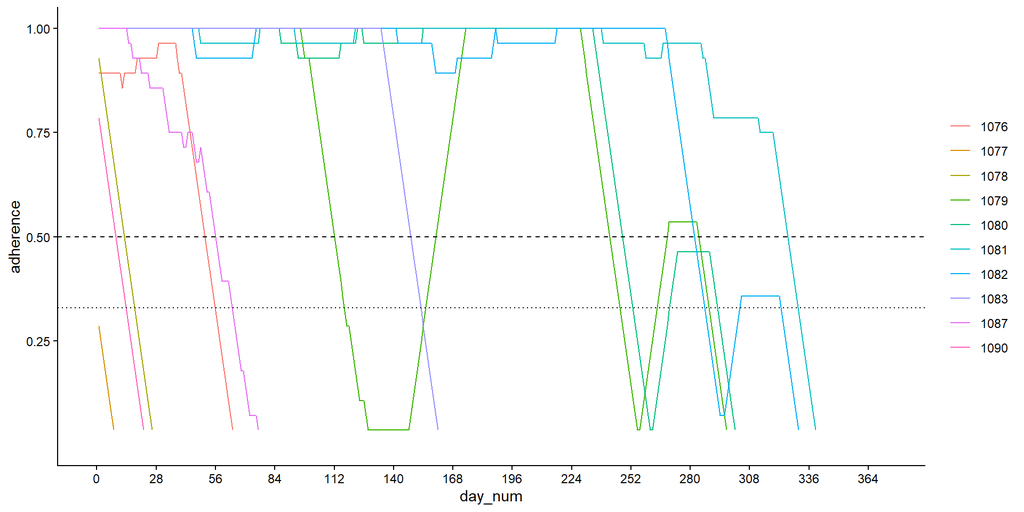

```
$`7`
```

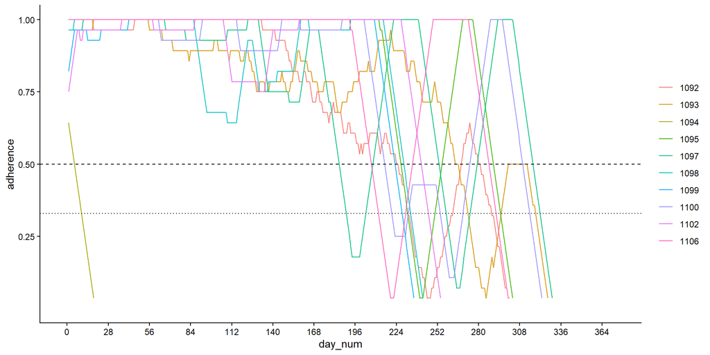

```
$`8`
```

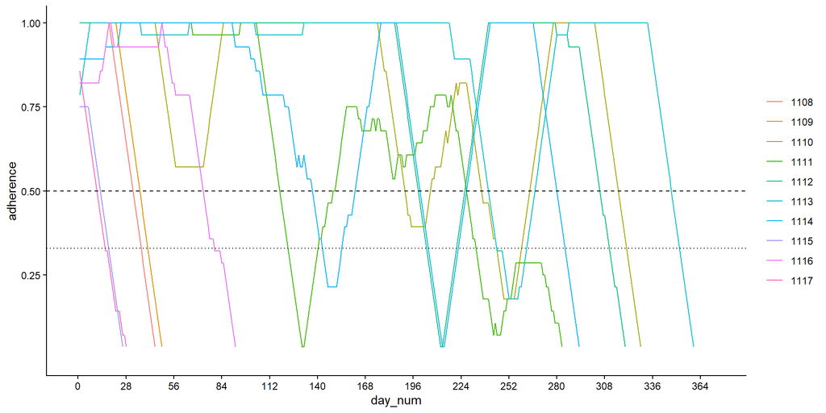

```
$`9`
```

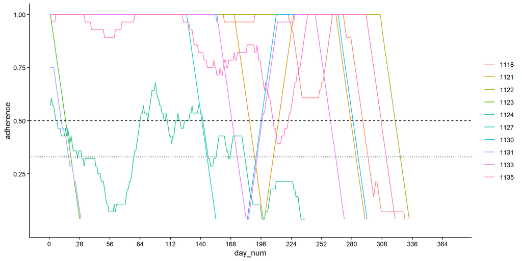

```
$`10`
```

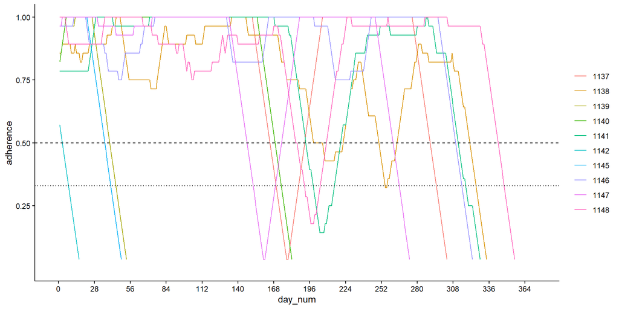

```
$`11`
```

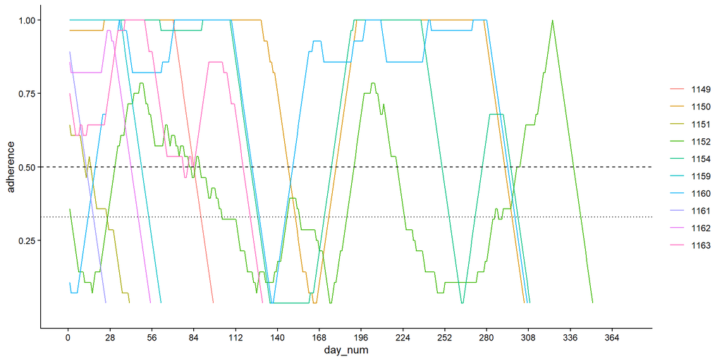

```
$`12`
```

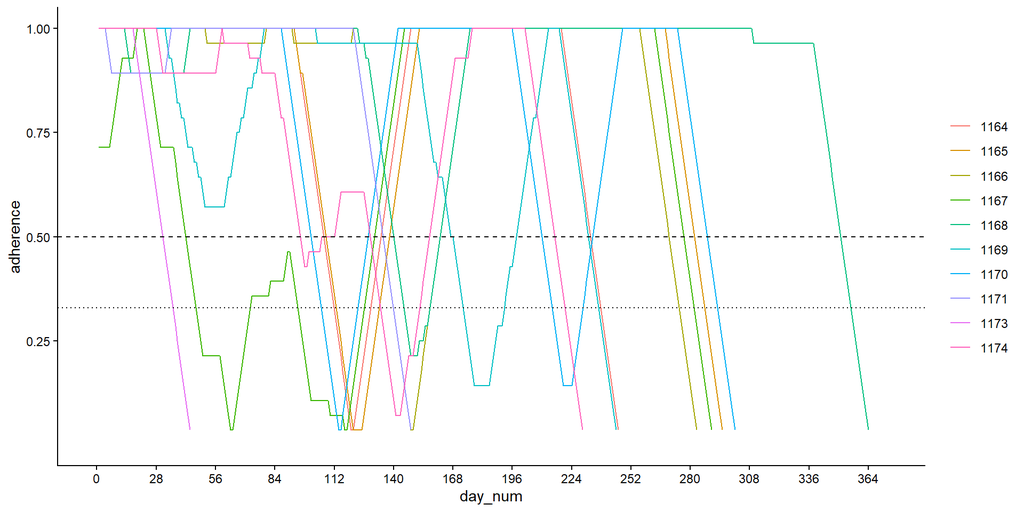

```
$`13`
```

[18 more figures not shown]

```r
subids <- unique(gps_count$subid)

# split into groups of 10 plotting
subid_groups <- split(subids, ceiling(seq_along(subids) / 10))

map(subid_groups, function(ids) {
  plot_1 <- gps_count |>
    filter(subid %in% ids) |>
    ggplot(aes(x = day_num, y = adherence,
               group = subid, color = factor(subid))) +
    geom_line() +
    scale_x_continuous(breaks = seq(0, 364, 28), limits = c(0, 372)) +
    scale_y_continuous(breaks = c(.25, .5, .75, 1.0), limits = c(0, 1)) +
    labs(color = NULL) +
    geom_hline(aes(yintercept = .50), linetype = "dashed") +
    geom_hline(aes(yintercept = .33), linetype = "dotted") +
    theme_classic()

  # plot_2 <- gps_heat_count |>
  #   filter(subid %in% ids) |>
  #   mutate(subid = factor(subid, levels = rev(ids))) |>
  #   ggplot(aes(x = week, y = subid, fill = n)) +
  #   geom_tile() +
  #   scale_fill_viridis_c(option = "C",
  #                        name = NULL,
  #                        na.value = "white") +
  #   scale_x_continuous(
  #     breaks = c(1, 4, 8, 12, 16, 20, 24, 28, 32, 36, 40, 44, 48, 52, 56,
  #                60, 64),
  #     limits = c(-1, 65),
  #     expand = c(0, 0)
  #   ) +
  #   labs(x = "Week number", y = "subid") +
  #   theme_minimal() +
  #   theme(panel.grid = element_blank()) +
  #   geom_vline(xintercept = 4) +
  #   geom_vline(xintercept = 52) +
  #   theme(legend.position = "bottom")

  plot_1
})
```